# Coursework Report

*N* removed NAs: 2

*N* removed typo: 1

*N* removed <18: 24

*N* total clean: 123

| Group | *N* | *M*<sub>age</sub> | *M*<sub>rating</sub> |
| --- | --- | --- | --- |
| Control | 65 | 21.46 | 5.64 |
| Experim | 58 | 21.43 | 6.69 |

**Main analysis results**

*t*(121) = -7.01, *p* < .001

[interactive chart not shown]

[figure not shown]

[interactive chart not shown]

# Coursework Report

Analysing Data, Spring 2020

# Methods

## Participants

The participants had a mean age of 21.45; ranging from 18 to 28 years, and a standard deviation of 2.57.

Table 1. Number of Participants in each Condition

| CONDITION | frequency |
| --- | --- |
| control | 65 |
| experimental | 58 |

## Design

The conceptual hypothesis in this study questions the influence of colour on perceived attractiveness in women viewing men. Participants were told the study was researching the first impressions of others.

This study used a between groups design. All participants were presented with a black and white photograph (4-in x 6-in) for five seconds depicting a young, reasonably attractive, brown-haired, caucasian male wearing a buttoned shirt. The independent measure was the colour of the border (4.5-in x 5-in) surrounding the photo. The independent measure had two levels: the colour white versus red. In the control condition, the border was white, and in the experimental condition, the border was red.

The dependent measure in this experiment was the perceived attractiveness of the male. This was measured with three face-valid items regarding the male’s attractiveness: “How attractive do you think this person is?” “How pleasant is this person to look at?” and “If I were to meet the person in this picture face to face, I would think he is attractive.” For each item, participants selected a value ranging from 1 to 9, where 1 means ‘not at all attractive’ and 9 means ‘extremely attractive’. This rating scale produced three continuous variables per participant which were then averaged to produce a composite score. This composite score quantified each participant’s level of attraction towards the man. A high composite score, for example a score of 8, implies the participant perceived the male to be highly attractive, and a low composite score, for example 2, implies a low perceived attractiveness.

The operationalised hypothesis asks whether having a red versus a white coloured frame around an image of a reasonably attractive male will significantly influence female participants’ mean rating of his attractiveness.

An independent measures t-test will compare the means of the composite scores from the control condition and the experimental condition to see whether colour had a significant impact on attractiveness ratings, or whether any difference occured due to chance.

# Results

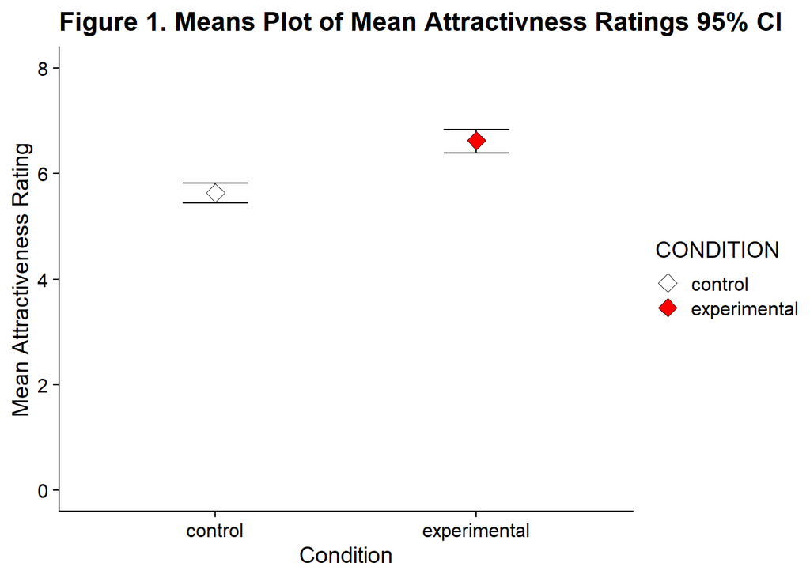

The general pattern of results suggest that participants in the experimental condition who viewed the photograph with a red border, rated the male’s attractivness higher than control participants whose photograph had a white border. This suggests that the colour red increases perceived attractiveness in women viewing men and supports the conceptual hypothesis.

| CONDITION | mean | sd | min | max |
| --- | --- | --- | --- | --- |
| control | 5.64 | 0.78 | 3.33 | 7.33 |
| experimental | 6.69 | 0.88 | 5.00 | 8.67 |

# Discussion

In the present research, we replicated the first experiment in Elliot et als (2010) ‘Red, rank and Romance in Women Viewing Men’ and found that participants in the red condition rated the male as significantly more attractive than those in the white condition. The results therefore accord with Elliot et als (2010) original findings and support the significance of the red effect.

This replication was necessary as the methodology of Elliot et als (2010) original research has received extensive criticism, and various independent laboratories have replicated the paradigm to find conflicting results. Critically, Francis (2013) applied the Ioannidis and Trikalinos test to the research and uncovered evidence of publication bias, as well as a lack of experimental power. Independent testing of the red effect was therefore requested, and the importance of sufficient test power emphasised. This replication carefully replicated the original paradigm, as well as using a substantially larger sample size (n = 123) than the meagre original (n = 21), and therefore provides valuable, impartial insight into the red effect.

There is a discordance in the original results of Elliot et al (2010) and replications. Peperkoorn, Roberts and Pollet (2016) conducted three replications of the paradigm, first with Dutch participants, then American, and finally with a larger sample (n = 830) and found in each experiment no evidence of a significant red effect (F(2, 199) =.08, p=.920). Further, Hesslinger, Goldbach and Carbon replicated the paradigm, as well as conducting a study with the addition of multiple men in different attire, and once again found no evidence of a significant red effect (t(87) = 0.92, p = 0.360). Elliot himself (Elliot, A. J., & Maier, M. A. 2013) replicated Experiment 3 and failed to find a significant difference between the red and grey condition (t = 1.51, p = .13, d = 0.25). Interestingly, Roberts, S. C., Owen, R. C., & Havlicek (2010) found that women wearing a red shirt were rated higher in attractiveness than women wearing yellow, blue, white or green, however, a black shirt also predicted a higher attractiveness rating. They concluded that colours do hold certain psychological associations which mediate perceptions of attractiveness, although the effect is not limited to the colour red.

The inconsistency between our pattern of results and other replications lead us to question the degree of influence colour has on perceived attractiveness. Perhaps the colour red has some influence, however the effect is not as consistent and significant as Eliot et al (2010) initially proposed.

There are a number of methodological flaws in this study that may constitute to a larger noise to signal ratio and explain the mixed data. Firstly, accurately replicating all aspects of a study is challenging and any unintentional alteration may increase the noise of the data (Brandt et al., 2014) However, this study largely abides by the “replication recipe” proposed by Brandt et al (2014, para. 6) as a solution to replication unreliability, perhaps indicating successful replication.

Further, the use of subjective 1-9 Likert scales reduces the internal validity of the dependent measure. The meaning of specific scores on the scale likely equate to subtly different definitions for each participant. In addition, an 11-point rating scale was employed in Peperkoorn, Roberts and Pollet’s (2016) replication to avoid a ceiling effect. Perhaps this extraneous variable explains the difference in results.

Crucially, mate-selection typically occurs in a naturalistic, ever-changing environment, and an immeasurable interplay of factors influence who we end up with. Factors such as facial attractiveness, eye-contact, posture and conversation, for example. In a real-world context, multiple factors interact and affect perceived attraction, whilst the controlled, laboratory conditions in this study reduces attraction to a black and white photograph and a rating scale. This clinical environment is an inaccurate reflection of real-life attraction and highlights the paradigm’s lack of ecological validity.

In sum, a lack of continuity in replication results suggest that colour (not specifically red) can influence male perceived attraction, however, its influence is small and largely insignificant. Instead of continuing to replicate Elliot et als (2010) methodologically flawed paradigm, research into how attraction is judged in a naturalistic environment, in addition to which factors have the greatest influence on attraction, would be worth investigating further.

Bibliography

Brandt, M. J., IJzerman, H., Dijksterhuis, A., Farach, F. J., Geller, J., Giner-Sorolla, R., Grange, J. A., Perugini, M., Spies, J. R., & van ’t Veer, A. (2014). The Replication Recipe: What makes for a convincing replication? Journal of Experimental Social Psychology, 50, 217–224.

Elliot, A. J., & Maier, M. A. (2013). The red-attractiveness effect, applying the Ioannidis and Trikalinos (2007b) test, and the broader scientific context: A reply to Francis (2013). Journal of Experimental Psychology: General, 142(1), 297–300.

Elliot, A. J., Niesta Kayser, D., Greitemeyer, T., Lichtenfeld, S., Gramzow, R. H., Maier, M. A., & Liu, H. (2010). Red, rank, and romance in women viewing men. Journal of Experimental Psychology: General, 139(3), 399–417.

Francis, G. (2013). Publication bias in “Red, rank, and romance in women viewing men,” by Elliot et al. (2010). Journal of Experimental Psychology: General, 142(1), 292–296.

Hesslinger, V. M., Goldbach, L., & Carbon, C.-C. (2015). Men in red: A reexamination of the red-attractiveness effect. Psychonomic Bulletin & Review, 22(4), 1142–1148.

Peperkoorn, L. S., Roberts, S. C., & Pollet, T. V. (2016). Revisiting the Red Effect on Attractiveness and Sexual Receptivity: No Effect of the Color Red on Human Mate Preferences. Evolutionary Psychology, 14(4), 147470491667384.

Roberts, S. C., Owen, R. C., & Havlicek, J. (2010). Distinguishing between Perceiver and Wearer Effects in Clothing Color-Associated Attributions. Evolutionary Psychology, 8(3), 147470491000800320.